# 데이터 과학 – 기초 통계

이항분포 근사 - 정규분포, 포아송 분포

## 1. 정규 분포로 근사

$n, np, n(1-p)$가 클 경우 이항분포를 정규분포로 근사할 수 있다. 즉, 이항분포 대신에 일부 차이가 있지만 정규분포를 사용해도 크게 무리가 없다.

$$X \sim \text{정규분포}(\mu, \sigma)$$

$\mu, \sigma$는 이항분포에서 다음 기대값과 표준편차값을 구해 사용한다.

- $\mu = np$
- $\sigma = \sqrt{np(1-p)}$

### 1.1. 정규분포 근사 R 시각화

이항분포에서 나온 평균과 표준편차를 정규분포에 넣어 난수를 뽑고, 이항분포 난수와 시각적으로 비교하면 이항분포인지 정규분포인지 시각적으로 구분이 쉽지 않다.

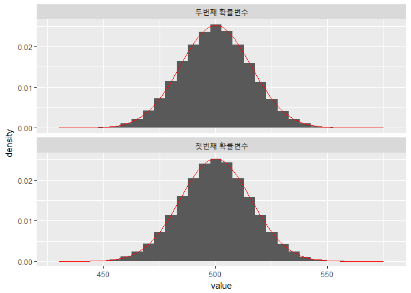

```r
# 1. 이항분포를 정규분포에 근사 ------------
size <- 1000
prob <- 0.5

binom_smpl <- rbinom(100000, size, prob)

expected_value <- size * prob
variance <- size * prob * (1-prob)
stdev <- sqrt(variance)

normal_smpl <- rnorm(100000, expected_value, stdev)

approx_normal <- function(rv_01, rv_02){
  rv_01_df <- data.frame(value = rv_01, random_variable = "첫번째 확률변수")
  rv_02_df <- data.frame(value = rv_02, random_variable = "두번째 확률변수")
  rv_df <- bind_rows(rv_01_df, rv_02_df)

  rv_df %>%
    ggplot(aes(value)) +
      geom_histogram(aes(y = ..density..)) +
      stat_function(fun=dnorm, args = list(mean=expected_value, sd=stdev), color="red") +
      facet_wrap(~random_variable,nrow = 2)
}

approx_normal(binom_smpl, normal_smpl)
```

## 2. 포아송 분포로 근사

시행횟수 크고, 확률이 적은 경우 이항분포 대신에 포아송 분포에 근사가 된다. 따라서, 이항분포 대신 포아송분포를 사용해도 크게 무리가 없다.

$$X \sim \text{포아송}(\lambda)$$

포아송분포는 평균과 분산이 동일하게 $\lambda$다. 즉,

- $E(X) = \lambda$
- $Var(X) = \lambda$

### 2.1. 포아송 근사 R 시각화

시행횟수가 상당히 크고(1000), 확률이 매우 적은 (0.1%) 이항분포에서 표본을 뽑고, 동일한 기대값을 갖는 포아송분포에서 표본을 뽑아 시각적으로 비교한다.

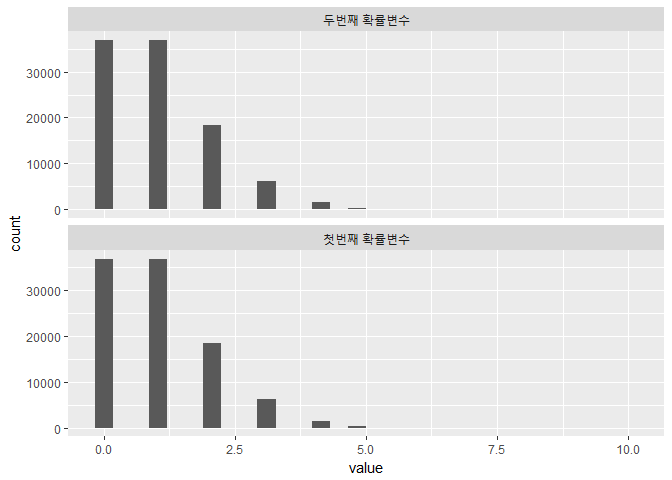

```r
# 2. 이항분포를 포아송분포에 근사 ------------
size <- 1000
prob <- 0.001

binom_smpl <- rbinom(100000, size, prob)

pois_smpl <- rpois(100000, 1)

expected_value <- size * prob

approx_poisson <- function(rv_01, rv_02){
  rv_01_df <- data.frame(value = rv_01, random_variable = "첫번째 확률변수")
  rv_02_df <- data.frame(value = rv_02, random_variable = "두번째 확률변수")
  rv_df <- bind_rows(rv_01_df, rv_02_df)

  rv_df %>%
    ggplot(aes(value)) +
    geom_histogram(aes(y = ..count..)) +
    facet_wrap(~random_variable, nrow = 2)
}

approx_poisson(binom_smpl, pois_smpl)
```